« Retour au Portfolio

# Exos2_Prédiction

### Exercice 1 : écrire une fonction pour calculer MSE

Étant donné les listes de valeurs vraies et de prédictions, écrivez une fonction qui calcule le MSE de ces données.

INDICE

- L'utilisation de tableaux numpy rendra cela beaucoup plus facile.

```python
import numpy as np
import pandas as pd
import matplotlib.pyplot as plt
```

```python
true_values = [13.9, 20.3, 2.1, 8.8, 5.2]
predicted_vals = [14.3, 18.9, 3.4, 8.9, 5.0]
```

MSE c'est

- la moyenne des différence
- la somme des différence au carrée

```python
# Mean Squared Error MSE en python

def mse(true_values, predicted_vals):
    values = 0
    for i in range(len(predicted_vals)):
        values += (predicted_vals[i] - true_values[i])**2
    print(values / len(predicted_vals))
```

```python
mse(true_values, predicted_vals)
```

```
0.7720000000000011
```

```python
# Mean Squared Error MSE en python avec numpy

def calcul_mse(true_values, predicted_vals):

    """ y_true : Valeurs réelles (observées)
        y_pred : Valeurs prédites par le modèle"""

    #convertir en tableaux numpy
    y_true=np.array(true_values)
    y_pred=np.array(predicted_vals)

    #calcul du MSE
    mse=np.mean((y_true-y_pred)**2)
    print("Mean Squared Error (MSE) =", mse)
    return mse

calcul_mse([13.9, 20.3, 2.1, 8.8, 5.2], [14.3, 18.9, 3.4, 8.9, 5.0])
```

```
Mean Squared Error (MSE) = 0.7720000000000011
```

```
np.float64(0.7720000000000011)
```

```python
y_true = np.array(true_values) # le np.array crée un tableau numpy

y_true
```

```
array([13.9, 20.3,  2.1,  8.8,  5.2])
```

## Exercice 2 : Prédiction par régression linéaire des prix de l'immobilier

Le marché immobilier californien est en plein essor et, comme c'est le siège de la Silicon Valley, la société immobilière **Homes4You** a décidé d'utiliser de nouvelles techniques de science des données pour soutenir son activité. Ils veulent que vous construisiez un modèle prédictif qui fournit le prix médian de l'immobilier pour chaque zone locale de l'État (ces zones locales sont souvent appelées * « blocs »*). Ils l'utiliseront pour guider leurs agents dans la manière de fixer le prix des maisons.

Ils ont rassemblé un ensemble de données avec de nombreuses fonctionnalités pour vous aider à créer votre modèle. Cependant, ils préfèrent inclure le moins de fonctionnalités possible afin de minimiser le temps que leurs agents passeront à collecter des données à l'avenir.

Votre mission est d'appliquer un modèle de régression pour prédire les prix des logements en Californie.

1. - Importez les données collectées par l'entreprise à l'aide de la fonction sklearn `fetch_california_housing`
2. - Faire une heatmap des coefficients de corrélation entre les variables
3. - Divisez les données en un ensemble de formation et de test
4. - Construisez un modèle de régression linéaire en utilisant toutes les variables disponibles et imprimez les scores MSE d'entraînement et de test.
5. - Essayez de créer d'autres modèles avec différentes combinaisons de variables. Imprimez les scores MSE d'entraînement et de test d'au moins 2 de ces modèles.
6. - Fournissez une recommandation à Homes4You sur les variables que vous incluriez dans le modèle.
7. - Imprimez les scores d'entraînement et de test **RMSE** de votre modèle final et expliquez en quelques phrases à Homes4You les performances de votre modèle.

```python
import pandas as pd
import numpy as np
import seaborn as sns
import matplotlib.pyplot as plt
```

1. Importez les données collectées par l'entreprise Approche pédagogique : Nous utilisons la fonction fetch_california_housing de scikit-learn pour charger le jeu de données. Pour faciliter la manipulation et l'exploration, nous le convertissons immédiatement en DataFrame Pandas, une pratique standard en data analysis.

```python
from sklearn.datasets import fetch_california_housing
# Charger le jeu de données
housing = fetch_california_housing()

# Convertir les données en DataFrame Pandas
X = pd.DataFrame(housing.data, columns=housing.feature_names)
y = pd.Series(housing.target, name='MedHouseVal') # La cible est le prix médian

print("Aperçu des 5 premières lignes des variables (X):")
X.head()
```

```
Aperçu des 5 premières lignes des variables (X):
```

|  | MedInc | HouseAge | AveRooms | AveBedrms | Population | AveOccup | Latitude | Longitude |
| --- | --- | --- | --- | --- | --- | --- | --- | --- |
| 0 | 8.3252 | 41.0 | 6.984127 | 1.023810 | 322.0 | 2.555556 | 37.88 | -122.23 |
| 1 | 8.3014 | 21.0 | 6.238137 | 0.971880 | 2401.0 | 2.109842 | 37.86 | -122.22 |
| 2 | 7.2574 | 52.0 | 8.288136 | 1.073446 | 496.0 | 2.802260 | 37.85 | -122.24 |
| 3 | 5.6431 | 52.0 | 5.817352 | 1.073059 | 558.0 | 2.547945 | 37.85 | -122.25 |
| 4 | 3.8462 | 52.0 | 6.281853 | 1.081081 | 565.0 | 2.181467 | 37.85 | -122.25 |

2. Faire une heatmap des coefficients de corrélation entre les variables

**Une heatmap** Nous permet de visualiser rapidement les relations entre toutes les variables. Des couleurs vives (proches de 1 ou -1) indiquent une **forte corrélation.** C'est un outil essentiel pour comprendre quelles variables sont les plus liées au **prix des maisons (MedHouseVal)** et si certaines variables sont redondantes entre elles.

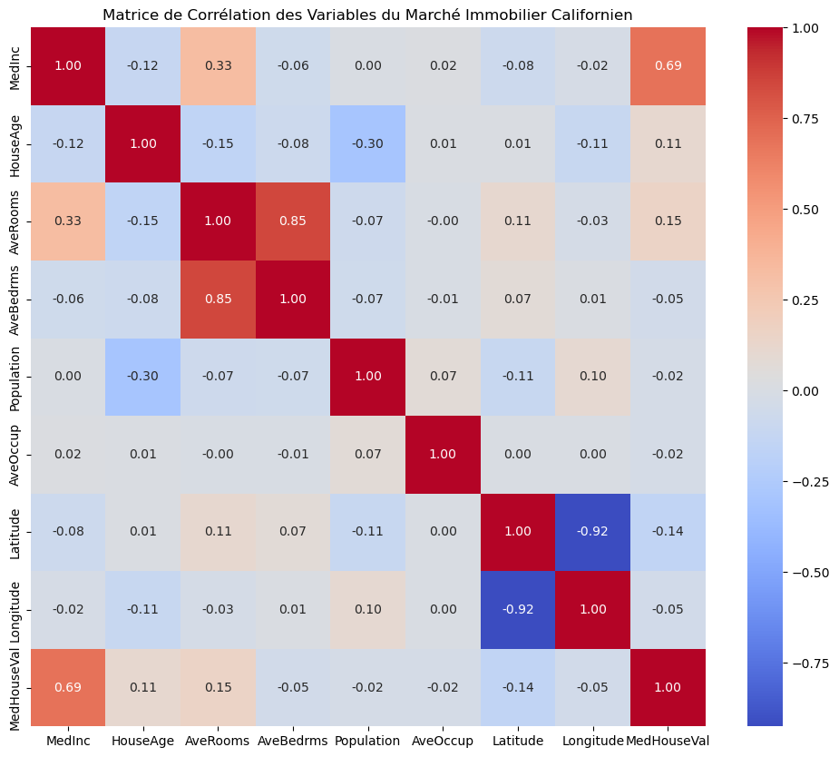

```python
# Combiner les variables et la cible en un seul DataFrame pour la corrélation
df_full = pd.concat([X, y], axis=1)

# Calculer la matrice de corrélation
corr_matrix = df_full.corr()

# Créer la heatmap
plt.figure(figsize=(12, 10))
sns.heatmap(corr_matrix, annot=True, fmt=".2f", cmap='coolwarm')
plt.title("Matrice de Corrélation des Variables du Marché Immobilier Californien")
plt.show()
```

**On remarque** MedInc (revenu médian) est la variable la plus corrélée positivement avec le prix des maisons (MedHouseVal).

3. - Divisez les données en un ensemble de formation et de test

```python
from sklearn.model_selection import train_test_split

X_train, X_test, y_train, y_test = train_test_split(X, y, test_size=0.2, random_state=42)

#42 c'est un beau chiffre c'est un nb parfait

print(f"Taille de l'ensemble d'entraînement : {X_train.shape[0]} lignes")
print(f"Taille de l'ensemble de test : {X_test.shape[0]} lignes")
```

```
Taille de l'ensemble d'entraînement : 16512 lignes
Taille de l'ensemble de test : 4128 lignes
```

4. - Construisez un modèle de régression linéaire en utilisant toutes les variables disponibles et imprimez les scores MSE d'entraînement et de test.

### J'entraine avec X_train.shape

```python
from sklearn.linear_model import LinearRegression
# La 1ére maniére de faire cf plus haut Allez plus HAUT !!! Cours

# Initialiser et entraîner le modèle
model_all_vars = LinearRegression()
model_all_vars.fit(X_train, y_train)

#### Prédire sur les deux ensembles
# 1.Prédictions pour le X_train
y_pred_train_all = model_all_vars.predict(X_train)

# 2.Prédictions pour le X_test
y_pred_test_all = model_all_vars.predict(X_test)

print (f"le prédict train donne : {y_pred_train_all}")
print (f"le prédict test donne : {y_pred_test_all}")
```

```
le prédict train donne : [1.93725845 2.48910616 2.64735483 ... 2.03879912 2.84075139 2.27373156]
le prédict test donne : [0.71912284 1.76401657 2.70965883 ... 4.46877017 1.18751119 2.00940251]
```

```python
# La 2 éme maniére de faire cf vidéo NoteBook 2a

# On refait X_Train
model_all_vars = LinearRegression()  # On change juste le nom du modéle pour comparer
model_all_vars.fit(X_train, y_train)
model_all_vars.score(X_train, y_train)
y_pred_train_all2 = model_all_vars.predict(X_train)

# On refait X_test
y_pred_test_all2 = model_all_vars.predict(X_test)

print (f"le prédict train donne : {y_pred_train_all2}")
print (f"le prédict test donne : {y_pred_test_all2}")
```

```
le prédict train donne : [1.93725845 2.48910616 2.64735483 ... 2.03879912 2.84075139 2.27373156]
le prédict test donne : [0.71912284 1.76401657 2.70965883 ... 4.46877017 1.18751119 2.00940251]
```

### Je Test les MSE

```python
from sklearn.metrics import mean_squared_error    # Pour le  M  ean  S  quared   E  rror

# Calculer et afficher les scores MSE
mse_train_all = mean_squared_error(y_train, y_pred_train_all)  # On donne les 2 valeurs x et y train
mse_test_all = mean_squared_error(y_test, y_pred_test_all) # On donne les 2 valeurs x et y test

print(f"Modèle avec toutes les variables - MSE Test : {mse_test_all:.4f}")
print(f"Modèle avec toutes les variables - MSE Entraînement : {mse_train_all:.4f}")
```

```
Modèle avec toutes les variables - MSE Test : 0.5559
Modèle avec toutes les variables - MSE Entraînement : 0.5179
```

Les MSE d'entraînement (0.52) et de test (0.55) sont similaire et **la quantité d'erreur est basse** (en ratio du fichier sur lequel on fait le test) Y a pas eu de perte entre modéle entrainement et test donc c'est plutôt pas mal/bien /incroyable/formidable/fabuleux

- GOOD JOB
5. - Essayez de créer d'autres modèles avec différentes combinaisons de variables. Imprimez les scores MSE d'entraînement et de test d'au moins 2 de ces modèles.

L'entreprise souhaite un modèle simple. Nous allons donc tester deux modèles avec moins de variables, en nous basant sur la heatmap de corrélation pour choisir les plus pertinentes.

```python
# Leave out these columns and then compute the training and testing MSE
to_drop = ['AveRooms', 'AveBedrms', 'Population', 'AveOccup']
```

```python
# --- Modèle 1 : Basé sur les 2 variables les plus corrélées ---
features_model_1 = ['MedInc', 'AveRooms']  # Variables choisies
model_1 = LinearRegression()
model_1.fit(X_train[features_model_1], y_train)
mse_train_1 = mean_squared_error(y_train, model_1.predict(X_train[features_model_1]))
mse_test_1 = mean_squared_error(y_test, model_1.predict(X_test[features_model_1]))

print(f"Modèle 1 ({features_model_1}) - MSE Entraînement : {mse_train_1:.4f}")
print(f"Modèle 1 ({features_model_1}) - MSE Test : {mse_test_1:.4f}")
```

```
Modèle 1 (['MedInc', 'AveRooms']) - MSE Entraînement : 0.6910
Modèle 1 (['MedInc', 'AveRooms']) - MSE Test : 0.7022
```

```python
# --- Modèle 2 : Modèle avec 4 variables pertinentes ---
features_model_2 = ['MedInc', 'AveRooms', 'HouseAge', 'AveOccup']
model_2 = LinearRegression()
model_2.fit(X_train[features_model_2], y_train)
mse_train_2 = mean_squared_error(y_train, model_2.predict(X_train[features_model_2]))
mse_test_2 = mean_squared_error(y_test, model_2.predict(X_test[features_model_2]))

print(f"\nModèle 2 ({features_model_2}) - MSE Entraînement : {mse_train_2:.4f}")
print(f"Modèle 2 ({features_model_2}) - MSE Test : {mse_test_2:.4f}")
```

```
Modèle 2 (['MedInc', 'AveRooms', 'HouseAge', 'AveOccup']) - MSE Entraînement : 0.6451
Modèle 2 (['MedInc', 'AveRooms', 'HouseAge', 'AveOccup']) - MSE Test : 0.6575
```

6. - Fournissez une recommandation à Homes4You sur les variables que vous incluriez dans le modèle.

7. - Imprimez les scores d'entraînement et de test **RMSE** de votre modèle final et expliquez en quelques phrases à Homes4You les performances de votre modèle.

Le RMSE (racine carrée du MSE) est plus facile à interpréter car il est dans la même unité que la cible (le prix). Nous le comparons à la distribution des prix pour donner un contexte à l'erreur.

```python
# Calculer le RMSE pour le modèle final (Modèle 2)
rmse_train_final = np.sqrt(mse_train_2) # sqrt = racine carrée peut ce faire avec **0.5
rmse_test_final = np.sqrt(mse_test_2)   # mse_test_final = mse_test_2**0.5

print(f"Modèle final - RMSE Entraînement : {rmse_train_final:.4f}")
print(f"Modèle final - RMSE Test : {rmse_test_final:.4f}")

# Afficher les statistiques descriptives
print(y.describe())
```

```
Modèle final - RMSE Entraînement : 0.8032
Modèle final - RMSE Test : 0.8108
count    20640.000000
mean         2.068558
std          1.153956
min          0.149990
25%          1.196000
50%          1.797000
75%          2.647250
max          5.000010
Name: MedHouseVal, dtype: float64
```

Explication pour Homes4You :

- Notre modèle final

Modéle 2 moins précis que l'initial, mais moins de variables à prendre en compte mais probablement plus rapide et facile d'utilisation. le RMSE du modéle 2 soit la racine carré de MSE semble confirmer le choix car plus proche de valeurs réelle mais bas et RMSE_train proche du RMSE_test du modéle 2.

### Tâche 3 : Expliquez cela à votre voisin...

**Les erreurs de formation et de test sont assez proches. Qu'est-ce que cela signifie?**

Les erreurs de formation et de test sont assez proches. Qu'est-ce que cela signifie? Cela signifie que le modèle généralise bien. Il n'a pas "appris par cœur" les données d'entraînement (ce qui serait de l'overfitting). Sa performance sur de nouvelles données qu'il n'a jamais vues est presque aussi bonne que sur les données qu'il connaît, ce qui est le signe d'un modèle robuste.

<détails>

**ASTUCE**

CONSEIL : réfléchissez à la question de savoir si nous devions appliquer ce modèle ajusté à de nouvelles données que le modèle n'a pas vues.

</détails>

**Si vos résultats MSE et RMSE sont différents de ceux de vos pairs (même en utilisant les mêmes fonctionnalités et le même modèle), pourquoi cela pourrait-il être le cas ?**

La raison la plus probable est que nous n'avons pas utilisé le même random_state dans la fonction train_test_split. Cette valeur fixe la manière dont les données sont réparties aléatoirement. Un random_state différent aboutit à des ensembles d'entraînement et de test légèrement différents, ce qui peut entraîner de petites variations dans les scores finaux.

### Tâche 4 :

**Essayez de charger le « prix de l'immobilier à Boston » (faites des recherches plus approfondies, quel est le problème ici ?).**

Ce jeu de données a été retiré des versions récentes de scikit-learn en raison de problèmes éthiques soulevés par la communauté. Une des variables (B) était basée sur une formule discriminatoire envers les populations noires. Tenter de le charger avec load_boston() génère désormais une erreur expliquant cette situation.

**Essayez de charger l'ensemble de données « Linnerrud » fourni avec sklearn ? Essayez de construire un modèle**

Le jeu de données Linnerrud est intéressant car il a plusieurs variables cibles (poids, tour de taille, pouls). On peut construire un modèle pour prédire l'une d'entre elles, par exemple le poids.

```python
from sklearn.datasets import load_linnerud

# Charger le dataset
linnerud = load_linnerud()

# On Affiche le dataset
print(linnerud.DESCR)
```

```
.. _linnerrud_dataset:

Linnerrud dataset
-----------------

**Data Set Characteristics:**

:Number of Instances: 20
:Number of Attributes: 3
:Missing Attribute Values: None

The Linnerud dataset is a multi-output regression dataset. It consists of three
exercise (data) and three physiological (target) variables collected from
twenty middle-aged men in a fitness club:

- *physiological* - CSV containing 20 observations on 3 physiological variables:
   Weight, Waist and Pulse.
- *exercise* - CSV containing 20 observations on 3 exercise variables:
   Chins, Situps and Jumps.

.. dropdown:: References

   * Tenenhaus, M. (1998). La regression PLS: theorie et pratique. Paris:
     Editions Technic.
```

```python
linnerud.data.shape
```

```
(20, 3)
```

```python
linnerud.target.shape
```

```
(20, 3)
```

```python
# On créer 2 DataFrames
X_lin = pd.DataFrame(linnerud.data, columns=linnerud.feature_names)

#Affiche les features c'est à dire les caractéristiques
print(X_lin.head())
```

```
   Chins  Situps  Jumps
0    5.0   162.0   60.0
1    2.0   110.0   60.0
2   12.0   101.0  101.0
3   12.0   105.0   37.0
4   13.0   155.0   58.0
```

```python
# On choisit le Target et on l'isole :
y_lin = pd.Series(linnerud.target[:, 0], name='Weight') # On prédit la première cible: le poids

# On l'affiche
print(y_lin)
```

```
0     191.0
1     189.0
2     193.0
3     162.0
4     189.0
5     182.0
6     211.0
7     167.0
8     176.0
9     154.0
10    169.0
11    166.0
12    154.0
13    247.0
14    193.0
15    202.0
16    176.0
17    157.0
18    156.0
19    138.0
Name: Weight, dtype: float64
```

```python
# Nous divisons le dataset en un ensemble d'entrainement et un ensemble de test
# from sklearn.model_selection import train_test_split (pas nécessaire car déjà importé)
X_train_lin, X_test_lin, y_train_lin, y_test_lin = train_test_split(X_lin, y_lin, random_state=18)

# j'ai mis 18 pour faire plaisirs au formateur qui va me valider mon Campus Skills bien entendus !!!!
```

```python
# from sklearn.linear_model import LinearRegression

# On entraine
model_lin = LinearRegression()
model_lin.fit(X_train_lin, y_train_lin)

# On predict
model_lin.predict(X_test_lin)

print (f"le predict lin donne : {model_lin.predict(X_test_lin)}")
```

```
le predict lin donne : [184.60020759 174.95919216 195.79311265 183.06163075 165.46956132]
```

```python
# MSE de lin
# from sklearn.metrics import mean_squared_error

mse_test_lin = mean_squared_error(y_test_lin, model_lin.predict(X_test_lin))
print(f"MSE du modèle Linnerrud pour prédire le poids : {mse_test_lin:.2f}")
```

```
MSE du modèle Linnerrud pour prédire le poids : 848.51
```